# 4 Monte Carlo Simulation and Variance Reduction

Monte Carlo (MC) integration is a simulation-based method for *approximating integrals* using random sampling.

In numerical integration, methods such as the trapezoidal rule use a *deterministic approach*. MC integration, on the other hand, employs a *non-deterministic* approach: each realization provides a different outcome.

## 4.1 What is Monte Carlo Simulation?

### 4.1.1 History

Monte Carlo (MC) is a casino in Monaco, famous for its gambling and games of chance. The term “Monte Carlo” was coined by physicists Stanislaw Ulam in the 1940s while working on nuclear weapon projects at Los Almos.

[figure not shown]

Monte Carlo Casino, Picture borrowed from Wikipedia

Monte Carlo methods are mainly used in three distinct problem classes:

1. optimization
2. numerical integration
3. generating draws from a probability distribution.

They can also be used to model phenomena with significant uncertainty in inputs, such as calculating the risk of a nuclear power plant failure. Monte Carlo methods are often implemented using computer simulations, and they can provide approximate solutions to problems that are otherwise intractable or too complex to analyze mathematically.

### 4.1.2 Key Steps of MC methods

Monte Carlo methods vary, but tend to follow a particular pattern:

1. Define a domain of possible inputs.
2. Generate inputs randomly from a probability distribution over the domain.
3. Perform a deterministic computation of the outputs.
4. Aggregate the results.

For example, consider a quadrant (circular sector) inscribed in a unit square. Given that the ratio of their areas is $\pi/4$, the value of $\pi$ can be approximated using the Monte Carlo method:

1. Draw a square, then inscribe a quadrant within it.
2. Uniformly scatter a given number of points over the square.
3. Count the number of points inside the quadrant, i.e. having a distance from the origin of less than 1.
4. The ratio of the inside-count and the total-sample-count is an estimate of the ratio of the two areas, $\pi/4$. Multiplying this ratio by 4 gives an estimate of $\pi$.

[figure not shown]

Picture borrowed from Wikipedia

## 4.2 Basic Monte Carlo Integration

To approximate the integral of a function $f(x)$ over the interval $[a, b]$, we can use the following formula:

Consider the problem of estimating $\theta = \int_0^1 g(x)dx$. If $X_1,\dots , X_m\sim\operatorname{Unif}(0,1)$, then the MC estimator is given by:

$$\hat{\theta}=\bar{g}_m(X)=\frac{1}{m}\sum_{i=1}^m g(X_i)$$
converges to $\mathbb{E}[g(X)]$ as $m\to\infty$ with probability 1, by *Strong law of Large Number* (SLLN). The simple MC estimator is unbiased, i.e., $\bar{g}_m(X)$.

Compute a MC estimate
$$\theta = \int_0^1 \exp(-x)dx,$$
and compare the estimate with the theoretical value

```r
set.seed(777)
n <- 1E3
x <- runif(n)
# simulated estimator
theta_hat <- exp(-x) |> mean()

# theoretical value
theta_true <- 1 - exp(-1)

# put them in a tibble
(results <- tibble(
  Method = c("Simulated", "Theoretical"),
  Value  = c(theta_hat, theta_true)))
```

```
# A tibble: 2 × 2
  Method      Value
  <chr>       <dbl>
1 Simulated   0.641
2 Theoretical 0.632
```

To simulate $\int_a^b g(t)dt$, use change of variable so the limit becomes from $0$ to $1$. This can be done through a *linear transformation* of the variable $t$: $y:=\frac{t-a}{b-a}$. Then, $t=a+(b-a)y$ and $dt=(b-a)dy$. Thus, we have
$$\int_a^b g(t)dt = (b-a)\int_0^1 g(a+(b-a)y)dy.$$
Alternatively, instead of using $\operatorname{Unif}(0,1)$, we can replace it with other densities with supports between $a$ and $b$. One instance is,
$$\int_a^b g(t)dt = \int_a^b \frac{g(t)}{f}f dt = (b-a) \int_a^b \frac{g(t)}{b-a} dt.$$
This is a $b-a$ times the expectation of $g(X)$ where $X\sim \operatorname{Unif}(a,b)$. Therefore, this integral can be estimated by averaging through the function $g(\cdot)$ over the interval from $a$ to $b$ multiply by $b-a$.

Compute a MC estimate of
$$\theta = \int_2^4 \exp(-x)dx,$$
and compare the estimate with the exact value of the integral.

```r
library(tibble)

set.seed(777)
m <- 1E3
x <- runif(m, min = 2, max = 4)

# simulated estimator
theta_hat <- exp(-x) |> mean() * (4 - 2)

# theoretical value
theta_true <- exp(-2) - exp(-4)

# put into tibble
(results <- tibble(
  Method = c("Simulated", "Theoretical"),
  Value  = c(theta_hat, theta_true)
))
```

```
# A tibble: 2 × 2
  Method      Value
  <chr>       <dbl>
1 Simulated   0.120
2 Theoretical 0.117
```

To summarize, the simple Monte Carlo estimator of the integral $\theta = \int_a^b g(x)dx$ is computed as follows.

1. Generate $X_1, \dots , X_m\overset{iid}{\sim}\operatorname{Unif}(a,b)$,
2. Compute $\bar{g}(X) = \frac{1}{m} g(X_i)$.
3. $\hat{\theta}= (b − a)\bar{g}(X)$.

Compute a MC estimate of a standard normal cdf

$$\Phi(x)=\int_{-\infty}^x \frac{1}{\sqrt{2 \pi}} e^{-t^2 / 2} d t$$

1. Note, we cannot apply the algorithm above directly because the limits of integration cover an *unbounded interval*. However, we can break this problem into two cases: (i) $x \ge 0$ and (ii) $x < 0$, and use the *symmetry* of the normal density to handle the second case. Then the problem is to estimate $\theta =\int_0^x \theta = \int_0^x \exp(−t^2/2) dt$ for $x > 0$. This can be done by generating random $\operatorname{Unif}(0,x)$ numbers, but it would mean changing the parameters of the uniform distribution for each different value of the cdf required. Suppose that we prefer an algorithm that always samples from $\operatorname{Unif}(0,1)$. This can be accomplished by a change of variables. Making the substitution $y = t/x$, we have $dt = x dy$ and

$$\theta=\int_0^1 x e^{-(x y)^2 / 2} d y$$
Thus, $\theta = \mathbb{E}_Y[x\exp(-(xY)^2/2)]$, where the rv $Y\sim \operatorname{Unif}(0,1)$. Generate iid $\operatorname{Unif}(0,1)$ random numbers $u_1,\dots,u_m$, and compute
$$\hat{\theta}=\overline{g_m(u)}=\frac{1}{m} \sum_{i=1}^m x e^{-\left(u_i x\right)^2 / 2}.$$

The sample mean $\hat{\theta}$ converges to $\mathbb{E}\hat{\theta}= \theta$ as $m\to \infty$. If $x > 0$, the estimate of $\Phi(x) = 1/2 + \hat{\theta}/\sqrt{2\pi}$. If $x < 0$ compute $\Phi(x) = 1 − \Phi(−x)$.

```r
x <- seq(.1, 2.5, length = 10)
m <- 10000
u <- runif(m)
cdf <- numeric(length(x))
for (i in 1:length(x)) {
  g <- x[i] * exp(-(u * x[i])^2 / 2)
  cdf[i] <- mean(g) / sqrt(2 * pi) + 0.5
}
Phi <- pnorm(x)
print(round(rbind(x, cdf, Phi), 3))
```

```
    [,1]  [,2]  [,3]  [,4]  [,5]  [,6]  [,7]  [,8]  [,9] [,10]
x   0.10 0.367 0.633 0.900 1.167 1.433 1.700 1.967 2.233 2.500
cdf 0.54 0.643 0.737 0.816 0.878 0.924 0.956 0.976 0.987 0.994
Phi 0.54 0.643 0.737 0.816 0.878 0.924 0.955 0.975 0.987 0.994
```

Notice that it would have been simpler to generate random Uniform(0, x) random variables and skip the transformation. In fact, the integrand of the previous example is itself a density function, and we can generate random variables from this density. This provides a more direct approach to estimating the integral.

Let $I(\cdot)$ be the indicator function, and $Z\sim N(0,1)$. Then for any constant $x$ we have $\mathbb{E}[I(Z ≤ x)] = P (Z ≤ x) =\Phi(x)$, the standard normal cdf evaluated at $x$.

Generate a random sample $z_1, \dots , z_m\sim N(0,1)$. Then the theoretical mean and sample mean are
$$\hat{\theta}= \frac{1}{m} \sum_{i=1}^m I(z_i \le x),$$
and
$$\mathbb{E}[\hat{\theta}] = P(Z \le x) = \Phi(x).$$

```r
set.seed(777)
x <- seq(0.1, 2.5, length = 10)
m <- 1E4
z <- rnorm(m)
dim(x) <- length(x)
p <- apply(x, MARGIN = 1,
  FUN = function(x, z) {mean(z < x)}, z = z)
Phi <- pnorm(x)

rbind(x, p, Phi) |> round(3)
```

```
     [,1]  [,2]  [,3]  [,4]  [,5]  [,6]  [,7]  [,8]  [,9] [,10]
x   0.100 0.367 0.633 0.900 1.167 1.433 1.700 1.967 2.233 2.500
p   0.544 0.645 0.740 0.818 0.881 0.926 0.957 0.976 0.986 0.993
Phi 0.540 0.643 0.737 0.816 0.878 0.924 0.955 0.975 0.987 0.994
```

**Note**

Summarizing, if $f (x)$ is a probability density function supported on a set A, (that is, $f (x) \ge 0$ for all $x\in\mathbb{R}$ and $\int_A f (x) = 1$), to estimate the integral
$$\theta = \int_A g(x)f (x)dx,$$
generate a random sample $x_1,\dots,x_m$ from the distribution $f (x)$, and compute the sample mean
$$\hat{\theta}= \frac{1}{m}\sum_{i=1}^mg(x_i).$$
Then $\hat{\theta}\overset{p}{\to}\theta$ by the weak law of large numbers (WLLN).

The standard error of $\hat{\theta}= \frac{1}{m}\sum_{i=1}^m g(x_i)$.

Recall that, $\mathbb{V}ar({\hat{\theta}})=\sigma^2/m$ where $\sigma^2 = \mathbb{V}ar\{g(X)\}$. When the distribution of $X$ is unknown, we substitute for $F_X$ the empirical distribution $F_m$ of the sample $x_1, \dots , x_m$. The variance of $\hat{\theta}$ can be estimated by
$$\frac{\hat{\sigma}^2}{m} = \frac{1}{m^2}\sum_{i=1}^m [g(x_i) - \bar{g}(x)]^2.$$

Note that
$$\frac{1}{m}\sum_{i=1}^m[g(x_i)-\bar{g}(x_i)]^2,$$
is the *plug-in estimate* of $\mathbb{V}ar\{g(X)\}$. That is, it is the variance of $U$ , where $U$ is uniformly distributed on the set of replicates $\{g(x_i)\}$. The corresponding estimated standard error of $\hat{\theta}$ is
$$\widehat{se}(\hat{\theta}) = \frac{\hat{\sigma}}{\sqrt{m}} = \frac{1}{m}\left\{\sum_{i=1}^m [ g(x_i)- \bar{g}(x)]^2\right\}^{1/2}.$$
The CLT implies
$$\frac{\hat{\theta}-E[\hat{\theta}]}{\sqrt{\mathbb{V}ar(\hat{\theta})}} \overset{D}{\to} N(0,1),$$
as $m\to\infty$. Hence, if $m$ is sufficiently large, $\hat{\theta}$ is approximately normal with mean $\theta$. The large-sample, approximately normal distribution of $\hat{\theta}$ can be applied to put confidence limits or error bounds on the MC estimate of the integral, and check for convergence

Compute the 95% confidence interval for $\Phi(2)$ and $\Phi(2.5)$.

```r
set.seed(777)
x <- 2
m <- 10000
z <- rnorm(m)
g <- (z < x) #the indicator function
v <- mean((g - mean(g))^2) / m
cdf <- mean(g)
c(cdf, v)
```

```
[1] 9.771000e-01 2.237559e-06
```

```r
c(cdf - 1.96 * sqrt(v), cdf + 1.96 * sqrt(v))
```

```
[1] 0.9741681 0.9800319
```

Q: What about $\Phi(2.5)$?

## 4.3 Variance and Efficiency

We have seen that a MC approach to estimating the integral $\int_a^b g(x)dx$ is to represent the integral as the expected value of a function of a uniform random variable. That is, suppose $X\sim \operatorname{Unif}(0,1)$, then $f(x) = (b-a)^{-1}$ for $x\in[a,b]$ and 0 otherwise, and
$$\begin{aligned}
\theta & =\int_a^b g(x) d x \\
& =(b-a) \int_a^b g(x) \frac{1}{b-a} d x=(b-a) E[g(X)]
\end{aligned}$$

Recall that, from *Algorithm 2*, the sample-mean MC estimator of the integral $\theta$ is computed as follows.

1. Generate $X_1, \dots , X_m\overset{iid}{\sim}\operatorname{Unif}(a,b)$,
2. Compute $\bar{g}(X) = g(X_i)/m$
3. $\hat{\theta}= (b − a)\bar{g}(X)$.

The sample mean $\bar{g}(X)$ has expected value $g(X)=\theta/(b-a)$ and variance $\mathbb{V}ar\{\bar{g}(X)\}=\mathbb{V}ar\{g(X)\}/m$. By CLT, $\bar{g}(X)$ is approximately normal for large $m$. Therefore, the variance of the MC estimator $\hat{\theta}$ is approximately normal with mean $\theta$ and variance $\mathbb{V}ar\{g(X)\}/m$.

**NoteExpectation, Variance and Distribution of theta hat**

The expectation and the variance of the MC estimator $\hat{\theta}$ are given by
$$\begin{align*}
\mathbb{E}[\hat{\theta}] & = \theta, \\
\mathbb{V}ar(\hat{\theta}) &= (b-a)^2 \mathbb{V}ar(\overline{g}(X))=\frac{(b-a)^2}{m} \mathbb{V}ar\{g(X)\} .
\end{align*}$$
Further more, by CLT, for large $m$, $\overline{g}(X)$ is approximately normally distributed, and with the mean and variance given above.

### 4.3.1 Hit-or-Miss Approach

The **“hit-or-miss”** approach to MC integration also uses a *sample mean* to estimate the integral, but the sample mean is taken over a *different sample* and **therefore this estimator has a different variance than the one we have above**.

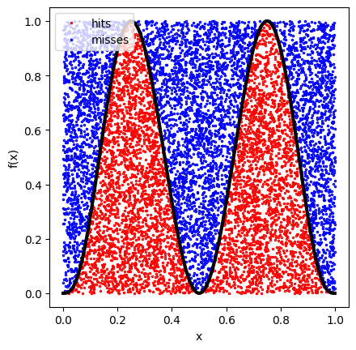

Hit-or-Miss MC, image borrowed from UBC

Suppose $f(x)$ is the density of a random variable $X$. The “hit-or-miss” approach to estimating $F(x) = \int_{-\infty}^x f(t)\,dt$ is as follows:

1. Generate a random sample $X_1,\dots,X_m \sim F_X(x)$.
2. For each observation $X_i$, compute
   $$g(X_i) = I(X_i \leq x) =
   \begin{cases}
   1, & X_i \leq x, \\
   0, & X_i > x.
   \end{cases}$$
3. Compute
   $$\hat{F}(x) = \frac{1}{m} \sum_{i=1}^m I(X_i \leq x).$$

Note that the random variable $Y = g(X) \sim \text{Bern}(1, p)$, where the success probability is
$$p := P(X \leq x) = F(x).$$

The transformed sample $Y_1, \ldots, Y_m$ are the outcomes of $m$ independent, identically distributed Bernoulli trials.

The estimator $\hat{F}(x)$ is the sample proportion
$$\hat{p} = \frac{y}{m},$$

where $y$ is the total number of successes observed in $m$ trials. Hence,

$$\mathbb{E}[\hat{F}(x)] = p = F(x), \qquad
\mathrm{Var}(\hat{F}(x)) = \frac{p(1-p)}{m} = \frac{F(x)\big(1-F(x)\big)}{m}.$$

The variance of $\hat{F}(x)$ can be estimated by
$$\frac{\hat{p}(1-\hat{p})}{m} = \frac{\hat{F}(x)\big(1-\hat{F}(x)\big)}{m}.$$

The maximum variance occurs when $F(x) = \tfrac{1}{2}$, so a conservative estimate of the variance of $\hat{F}(x)$ is
$$\frac{1}{4m}.$$

### 4.3.2 Efficiency

Suppose we have two (unbiased) estimators $\hat{\theta}_1$ and $\hat{\theta}_2$ for θ. We say $\hat{\theta}_1$ is *statistically* more efficient than $\hat{\theta}_2$ if
$$\mathbb{V}ar(\hat{\theta}_1) < \mathbb{V}ar(\hat{\theta}_2).$$
What is the variance of $\hat{\theta}_i$ is unknown or hard to be calculated?

can substitute it by sample estimate of the variance for each estimator.

Note, the variance can *always be reduced by increasing the number of replicates*, so computational efficiency is also relevant.

## 4.4 Variance Reduction

We have seen that MC integration may be used to estimate $\theta:=\mathbb{E}[g(X)]$. However, how to have the *efficient estimator* for $\theta$, and if we have a several ways $\hat{\theta}_1,\dots,\hat{\theta}_k$ to estimate $\theta$, which one is *better*, or, more efficient? Here, we try to introduce some variance reduction techniques.

Let $\hat{\theta}_1$ and $\hat{\theta}_2$ be two estimators of $\theta$ where $\mathbb{V}ar(\hat{\theta}_1) > \mathbb{V}ar(\hat{\theta}_2)$. The *relative efficiency gain* of $\hat{\theta}_2$ instead of using $\hat{\theta}_1$ is defined as
$$\operatorname{Eff}(\hat{\theta}_1, \hat{\theta}_2) = \frac{\mathbb{V}ar(\hat{\theta}_1)- \mathbb{V}ar(\hat{\theta}_2)}{\mathbb{V}ar(\hat{\theta}_1)}.$$

Let $X$ be a random object and let $g(\cdot)$ be a (possibly vector–valued) statistic of a *sample* from the distribution of $X$. For $j=1,\ldots,m$, draw an i.i.d. replicate sample $X^{(j)}=\{X^{(j)}_1,\ldots,X^{(j)}_n\}$ and compute
$$Y_j = g\!\big(X^{(j)}\big).
\tag{6.5}$$
Then $Y_1,\ldots,Y_m$ are i.i.d. with common mean
$$\theta \;=\; \mathbb{E}\big[g(X)\big] \;=\; \mathbb{E}[Y].$$

The MC estimator of $\theta$ is the sample mean
$$\hat{\theta}\;=\; \bar Y \;=\; \frac{1}{m}\sum_{j=1}^m Y_j.$$
By linearity of expectation,
$$\mathbb{E}[\hat{\theta}] \;=\; \theta,$$
so $\hat{\theta}$ is unbiased. Its variance is
$$\mathbb{V}ar(\hat{\theta})
\;=\; \mathbb{V}ar(\bar Y)
\;=\; \frac{\mathbb{V}ar\{g(X)\}}{m}.$$

Hence the standard error decays as $m^{-1/2}$. To reduce the standard error from $0.01$ to $0.0001$, one would need about $10000$ times as many replicates. More generally, if $\mathbb{V}ar\{g(X)\}=\sigma^2$ and we target standard error at most $\varepsilon$, then
$$m \;\ge\; \frac{\sigma^2}{\varepsilon^2}$$
replicates suffice (ignoring finite–$m$ effects).

The remainder of this note gives a minimal simulation illustrating the $1/\sqrt{m}$ behavior and provides a template for later variance–reduction sections (e.g., control variates, antithetic sampling, importance sampling).

### 4.4.1 Rule-of-thumb for target standard error

Given a target standard error $\varepsilon$, we can solve $\sqrt{\sigma^2/m} \le \varepsilon$ for $m$.

```r
sigma2_true <- 2
epsilon <- c(0.1, 0.05, 0.01, 0.005, 0.001)
required_m <- ceiling(sigma2_true / (epsilon^2))
data.frame(se_target = epsilon, m_needed = required_m)
```

```
  se_target m_needed
1     0.100    2e+02
2     0.050    8e+02
3     0.010    2e+04
4     0.005    8e+04
5     0.001    2e+06
```

> **Remark.** Increasing $m$ always reduces variance but can be costly. Variance–reduction techniques seek lower variance at the *same* $m$ (or similar compute), rather than increasing $m$ alone.

## 4.5 Antithetic Variables

Antithetic variables are a variance reduction technique used in MC simulation to improve the efficiency of estimators. The basic idea is to use pairs of negatively correlated random variables to reduce the variance of the estimator. Recall that the variance of two variables are
$$\mathbb{V}ar(X+Y) = \mathbb{V}ar(X) + \mathbb{V}ar(Y) + 2\mathbb{C}ov(X,Y),$$
where $\mathbb{C}ov(X,Y) =\mathbb{E}[XY] - \mathbb{E}[X] \mathbb{E}[Y]$. The covariance can be written as $\mathbb{C}ov(X,Y) = \rho_{YX} \sigma_X \sigma_Y$, where $\rho_{YX}$ is the correlation coefficient between $X$ and $Y$. If $X$ and $Y$ are negatively correlated, i.e., $\rho_{YX} < 0$, then $\mathbb{C}ov(X,Y) < 0$, which can lead to a reduction in the variance of the sum $X + Y$.

Random Variables $X$ and $Y$ on the same probability space are said to be *antithetic* if they are negatively correlated, i.e., $\mathbb{C}ov(X,Y) < 0$.

Now, consier two random variable $U_1$ and $U_2$ that follows the same distribution. Then, if we take the average of the two random variables, we have
$$\mathbb{V}ar\left(\frac{U_1 + U_2}{2}\right) = \frac{1}{4} \left\{\mathbb{V}ar(U_1) + \mathbb{V}ar(U_2) + 2\mathbb{C}ov(U_1,U_2)\right\},$$
which will be smaller than when the two variables are independent (in that case, the last term is 0). Hence, the idea here it to consider the case where the RVs are **negatively correlated.**

Suppose that $X_1, \dots , X_n$ are simulated via the ITM. For each of the m replicates we have generated $U_j \sim\operatorname{Unif}(0,1)$, and the corresponding $X^{(j)} = F^{−1}_X(U_j), j = 1, \dots, n$. From before, we know that if $U\sim\operatorname{Unif}(0,1)$, then $1 − U$ has the same distribution as $U$, but $U$ and $1 − U$ are negatively correlated. Then

$$Y_j = g(F^{−1}_X(U^{(j)}_1 ), \dots , F^{−1}_X(U_n^{(j)})),$$
and

$$Y_j^\prime = g(F^{−1}_X(1-U^{(j)}_1 ), . . . , F^{−1}_X(1-U_n^{(j)}))$$
have the same distribution. So the question now if, when will $Y_j^{\prime}$ and $Y_j$ be negatively correlated?

We will see that if $g(\cdot)$ is monotone, then $Y_j$ and $Y_j^{\prime}$ are negatively correlated.

Define $(x_1, . . . , x_n) \le (y_1, \dots , y_n)$ if $x_j ≤ y_j, j = 1, \dots, n$. An $n$-variate function $g := g(X_1, \dots, X_n)$ is increasing if it is increasing in its coordinates. That is, $g$ is increasing if $g(x_1,\dots, x_n) \le g(y_1, \dots, y_n)$ whenever $(x_1, \dots , x_n) \le (y_1, . . . , y_n)$. Similarly $g$ is decreasing if it is decreasing in its coordinates. Then $g$ is monotone if it is increasing or decreasing.

Let $X$ be a random varaible, and $f$ and $g$ are monotonic increasing functions. Then
$$\mathbb{E}[f(X)g(X)] \ge \mathbb{E}[f(X)]\mathbb{E}[g(X)].$$

It is actually a corollary of the above theorem.

Let $g := g(X_1, \dots, X_n)$ be monotonic, and $U_1, \dots, U_n \sim \operatorname{Unif}(0,1)$ be independent. Then

$$Y_j^\prime = g(F^{−1}_X(1-U_1 ), . . . , F^{−1}_X(1-U_n))$$
and
$$Y_j = g(F^{−1}_X(U_1 ), . . . , F^{−1}_X(U_n))$$
are **negatively correlated**.

Refer to the example 4, illustrating MC integration applied to estimate the standard normal cdf

$$\Phi(x)=\int_{-\infty}^x \frac{1}{\sqrt{2 \pi}} e^{-t^2 / 2} d t$$

Repeat the estimation using antithetic variables, and find the approximate reduction in standard error. In this example, after change of variable, the target parameter is $\theta = \mathbb{E}_U[x\exp\{-(xU)^2/2\}]$ where $U\sim\operatorname{Unif}(0,1)$.

By restricting the simualtion to the upper tail, the function $g$ is monotone, so the hypothesis of Theorem 2 is satisfied. Now, we generate $u_1,\dots,u_{m/2}\overset{iid}{\sim}\operatorname{Unif}(0,1)$, and compute the half of the replicates using
$$Y_j=g^{(j)}(u)=x e^{-\left(u_j x\right)^2 / 2}, \quad j=1, \ldots, m / 2,$$
as before, but also compute
$$Y_j^{\prime}=x e^{-\left(\left(1-u_j\right) x\right)^2 / 2}, \quad j=1, \ldots, m / 2 .$$

Thus, the sample mean is
$$\begin{aligned}
\hat{\theta}=\overline{g_m(u)} & =\frac{1}{m} \sum_{j=1}^{m / 2}\left(x e^{-\left(u_j x\right)^2 / 2}+x e^{-\left(\left(1-u_j\right) x\right)^2 / 2}\right) \\
& =\frac{1}{m / 2} \sum_{j=1}^{m / 2}\left(\frac{x e^{-\left(u_j x\right)^2 / 2}+x e^{-\left(\left(1-u_j\right) x\right)^2 / 2}}{2}\right)\\
& \to \mathbb{E}[\hat{\theta}] = \theta, \quad \text{as } m\to\infty.
\end{aligned}$$
If $x\ge 0$, the estimate is $\Phi(x) = 0.5 + \hat{\theta}/ \sqrt{2\pi}$, where as if $x< 0$, the estimate is $\Phi(x) = 1-\Phi(-x)$.

```r
MC.Phi <- function(x, R = 10000, antithetic = TRUE) {
  u <- runif(R / 2)
  if (!antithetic) {
    v <- runif(R / 2)
  } else {
    v <- 1 - u
  }
  u <- c(u, v)
  cdf <- numeric(length(x))
  for (i in 1:length(x)) {
    g <- x[i] * exp(-(u * x[i])^2 / 2)
    cdf[i] <- mean(g) / sqrt(2 * pi) + 0.5
  }
  cdf
}

x <- seq(.1, 2.5, length=5)
Phi <- pnorm(x)
set.seed(123)
MC_raw <- MC.Phi(x, anti = FALSE)
set.seed(123)
MC_anti <- MC.Phi(x)
print(round(rbind(x, MC_raw, MC_anti, Phi), 5))
```

```
           [,1]    [,2]    [,3]    [,4]    [,5]
x       0.10000 0.70000 1.30000 1.90000 2.50000
MC_raw  0.53983 0.75825 0.90418 0.97311 0.99594
MC_anti 0.53983 0.75805 0.90325 0.97132 0.99370
Phi     0.53983 0.75804 0.90320 0.97128 0.99379
```

```r
## For variance
m <- 1000
MC_raw <- MC_anti <- numeric(m)
x <- 1.95
for (i in 1:m) {
  MC_raw[i] <- MC.Phi(x, R = 1000, anti = FALSE)
  MC_anti[i] <- MC.Phi(x, R = 1000)
}
sd(MC_raw) |> round(6)
```

```
[1] 0.006875
```

```r
sd(MC_anti) |> round(6)
```

```
[1] 0.000439
```

```r
eff <- (var(MC_raw) - var(MC_anti))/var(MC_raw)
eff |> round(6)
```

```
[1] 0.995917
```

Conclusion: The antithetic variable approach achieved approximately 0.9959 reduction in variance at x = 1.95.

## 4.6 Control Variates

Control variates is another variance reduction technique used in MC simulation to improve the efficiency of estimators. The basic idea is to use a known variable that is correlated with the variable of interest to reduce the variance of the estimator.

Suppose there exists a function $f(\cdot)$ such that $\mu=\mathbb{E}[f(X)]$ is known, and $f(X)$ is correlated with $g(X)$. Then, we have, for a constant $c\in\mathbb{R}$, $\hat{\theta}_c = g(X) + c\{f(X) - \mu\}$ is also an unbiased estimator of $\theta$. The variance of $\hat{\theta}_c$ is
$$\mathbb{V}ar(\hat{\theta}_c) = \mathbb{V}ar\{g(X)\} + c^2\mathbb{V}ar\{f(X)\} + 2c\mathbb{C}ov\{g(X), f(X)\}.$$
This is a quadratic function in $c$, and it is minimized at
$$c^*=-\frac{\mathbb{C}ov\{g(X), f(X))\}}{\mathbb{V}ar\{f(X)\}}.$$
By plugging in this optimizer $c=c^\ast$, the resulting variance is
$$\mathbb{V}ar(\hat{\theta}_{c^\ast}) = \mathbb{V}ar\{g(X)\} - \frac{[\mathbb{C}ov\{g(X), f(X)\}]^2}{\mathbb{V}ar\{f(X)\}}.$$
This RV $f(X)$ is called a *control variate* for the estimator of $g(X)$. We can see that the $\mathbb{V}ar\{g(X)\}$ is reduced by the second term $[\mathbb{C}ov\{g(X), f(X)\}]^2/\mathbb{V}ar\{f(X)\}$, and the percentage of variance reduction is
$$100 \frac{[\mathbb{C}ov(g(X), f(X))]^2}{\mathbb{V}ar(g(X)) \mathbb{V}ar(f(X))}=100[\mathbb{C}orr(g(X), f(X))]^2 .$$
Thus, if $g(X)$ and $f(X)$ is strongly correlated, the variance will be reduced, and if they are uncorrelated, there is no reduction in variance.

TO estimate $c^*$, we need to estimate $\mathbb{C}ov\{g(X),f(X)\}$ and $\mathbb{V}ar\{f(X)\}$, which may be estimated using MC too, in the preliminary steps.

Use control variate approach to compute
$$\theta = \mathbb{E}[\exp(U)] =\int_0^1\exp(u)du,\quad \text{where } U\sim\operatorname{Unif}(0,1).$$
We can easily find the analytical solution $\theta=\exp(1) - \exp(0) = e - 1 = 1.718282$, but how to use the control variate approach to estimate $\theta$?

We can apply the simple MC approach where the variance is $\mathbb{V}ar\{g(U)\}/m$, where
$$\mathbb{V}ar(g(U))=\mathbb{V}ar\left(e^U\right)=\mathbb{E}\left[e^{2 U}\right]-\theta^2=\frac{e^2-1}{2}-(e-1)^2 \approx 0.2420$$

Then, the controlled estimator is $\hat{\theta}_{c^\ast}=\exp(U)-1.6903(U-0.5)$. With $m$ replications, we have
$$\begin{aligned}
m\mathbb{V}ar(\hat{\theta}_{c^\ast})
&=\operatorname{Var}\left(e^U\right)-\frac{\left[\operatorname{Cov}\left(e^U, U\right)\right]^2}{\operatorname{Var}(U)} \\ &=\frac{e^2-1}{2}-(e-1)^2-12\left(1-\frac{e-1}{2}\right) \\
& \doteq 0.2420356-12(0.1408591)^2 \\
& =0.003940175 .
\end{aligned}$$

Thus, the reduction in variance using the control variate compared with the simple Monte Carlo estimate is
$$100 \frac{1-0.003940175}{0.2429355} = 98.3781 \%$$
.

```r
set.seed(777)
m <- 10000
a <- - 12 + 6 * (exp(1) - 1)
U <- runif(m)
T1_MC <- exp(U) #simple MC
T2_cv <- exp(U) + a * (U - 1/2) #controlled
mean(T1_MC) |> round(6)
```

```
[1] 1.715071
```

```r
mean(T2_cv) |> round(6)
```

```
[1] 1.717789
```

```r
eff <- (var(T1_MC) - var(T2_cv)) / var(T1_MC)
eff |> round(4)
```

```
[1] 0.9835
```

## 4.7 Other methods

There are other variance reduction techniques, including

- Importance Sampling
- Stratified Sampling
- Stratified Importance Sampling

Due to the limited amount of time we have, we will not go over those methods here. Interested readers may refer to the references below.

Reference used:

- Chapter 6 of Rizzo, M.L. (2007). *Statistical Computing with R*. CRC Press, Roca Baton.
- Monte Carlo Method page on Wikiepdia, [Link](https://en.wikipedia.org/wiki/Monte_Carlo_method).
- Wasserman, L. (2003). [*All of Statistics: A Concise Course in Statistical Inference*](https://egrcc.github.io/docs/math/all-of-statistics.pdf).